# Escuela Politécnica Nacional

**Nombre:** Francisco Ulloa  
**Fecha:** Quito, 5 de enero de 2026  
**Tema:** Eliminación Gaussiana vs Gauss-Jordan  
**Repositorio:**  
https://github.com/Fu5CHAR/Metodos_numericos_2025B_Ulloa-Francisco/tree/main

```python
from tarea09_funciones import *
```

[output not shown]

**1. Para cada uno de los siguientes sistemas, lineales, obtenga, de ser posible, una soluciòn con métodos gráficos. Explique los resultados desde un punto de vista geométrico.**

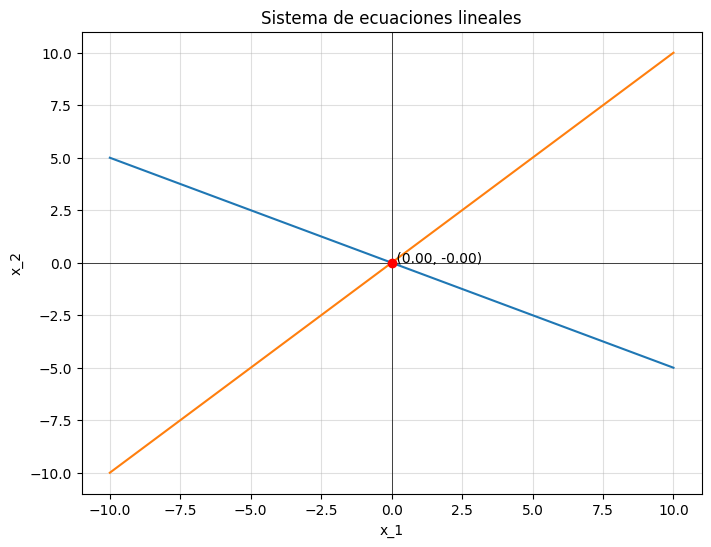

```python
resolver_y_graficar("x_1 + 2*x_2 = 0", "x_1 - x_2 = 0")
```

**b.**  
$x_1 + x_2 = 3\\$ $ -2x_1 -4x_2 = 6\$

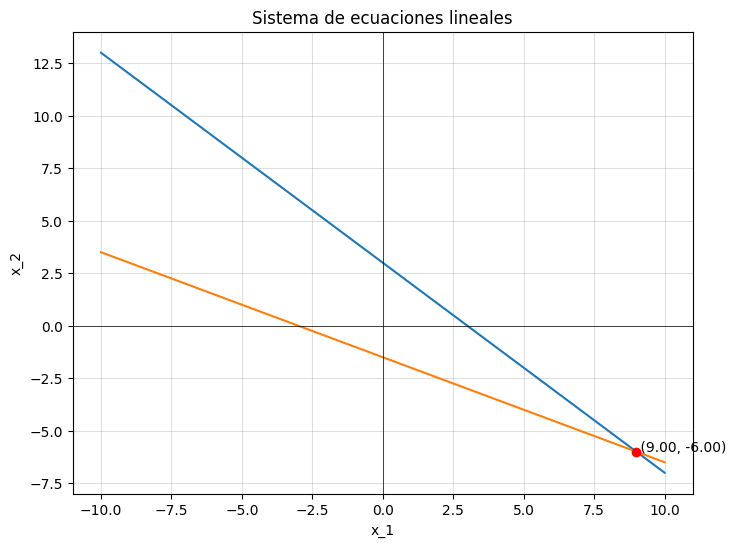

```python
resolver_y_graficar('x_1 + x_2 = 3', '-2*x_1 -4*x_2 = 6')
```

**c.**  
$2x_1 + x_2 = -1\\$ $x_1 + x_2 = 2\$ $x_1 - 3x_2 = 5$

```python
resolver_y_graficar('2*x_1 + x_2 = -1', 'x_1 + x_2 = 2', 'x_1 - 3*x_2 = 5')
```

```
El sistema no tiene solución única.
```

**d.**  
$2x_1 + x_2 + x_3 = 1\\$ $2x_1 + 4x_2 -x_3 = -1$

```python
resolver_y_graficar('2*x_1 + x_2 + x_3 = 1', '2*x_1 +4*x_2 -x_3 = -1')
```

```
El sistema no tiene solución única.
```

**a.**  
$ -x_1 + 4x_2 + x_3 = 8\\$ $\frac{5}{3}x_1 + \frac{2}{3}x_2 + \frac{2}{3}x_3 = 1\$ $2x_1 + x_2 + 4x_3 = 11$

```python
Ab= [[-1, 4, 1, 8],[5/3, 2/3, 2/3, 1],[2, 1, 4, 11]]
eliminacion_gaussiana_redondeo(Ab)
```

```
[01-07 17:23:50][INFO]
[[-1.    4.    1.    8.  ]
 [-0.    7.35  2.34 14.36]
 [ 0.    9.    6.   27.  ]]
[01-07 17:23:50][INFO]
[[-1.    4.    1.    8.  ]
 [-0.    7.35  2.34 14.36]
 [ 0.    0.03  3.15  9.48]]
```

```
array([-0.99,  1.  ,  3.01])
```

```python
b = [-1, 2, 3]
calcular_error(eliminacion_gaussiana_redondeo(Ab),b)
```

```
[01-07 17:23:50][INFO]
[[-1.    4.    1.    8.  ]
 [-0.    7.35  2.34 14.36]
 [ 0.    9.    6.   27.  ]]
[01-07 17:23:50][INFO]
[[-1.    4.    1.    8.  ]
 [-0.    7.35  2.34 14.36]
 [ 0.    0.03  3.15  9.48]]

Error calculado para la variable x 1 : 1.010101010101011 %

Error calculado para la variable x 2 : 100.0 %

Error calculado para la variable x 3 : 0.3322259136212554 %
```

**b.**  
$4_x + 2x_2 - x_3 = -5\\$ $\frac{1}{9}x_1 + \frac{1}{9}x_2 - \frac{1}{3}x_3 = -1\$ $x_1 + 4x_2 + 2x_3 = 9$

```python
Cd=[[4, 2, -1, -5],[1/9, 1/9, -1/3, -1],[1, 4, 2, 9]]
eliminacion_gaussiana_redondeo(Cd)
```

```
[01-07 17:23:50][INFO]
[[ 4.000e+00  2.000e+00 -1.000e+00 -5.000e+00]
 [-1.000e-02  5.000e-02 -3.000e-01 -8.500e-01]
 [ 0.000e+00  3.500e+00  2.250e+00  1.025e+01]]
[01-07 17:23:50][INFO]
[[ 4.000e+00  2.000e+00 -1.000e+00 -5.000e+00]
 [-1.000e-02  5.000e-02 -3.000e-01 -8.500e-01]
 [ 0.000e+00  0.000e+00  2.325e+01  6.975e+01]]
```

```
array([-1.,  1.,  3.])
```

```python
calcular_error(eliminacion_gaussiana_redondeo(Cd),b)
```

```
[01-07 17:23:50][INFO]
[[ 4.000e+00  2.000e+00 -1.000e+00 -5.000e+00]
 [-1.000e-02  5.000e-02 -3.000e-01 -8.500e-01]
 [ 0.000e+00  3.500e+00  2.250e+00  1.025e+01]]
[01-07 17:23:50][INFO]
[[ 4.000e+00  2.000e+00 -1.000e+00 -5.000e+00]
 [-1.000e-02  5.000e-02 -3.000e-01 -8.500e-01]
 [ 0.000e+00  0.000e+00  2.325e+01  6.975e+01]]

Error calculado para la variable x 1 : 0.0 %

Error calculado para la variable x 2 : 100.0 %

Error calculado para la variable x 3 : 0.0 %
```

**3.Utilice el algoritmo de eliminación gaussiana para resolver, de ser posible, los siguientes sistemas lineales, y determine si se necesitan intercambios de fila:**

**a.**  
$x_1 - x_2 + 3x_3 = 2\\$ $3x_1 -3x_2 + x_3 = -1\$ $x_1 + x_2 = 3$

```python
Ba=[[1, -1, 3, 2],[3, -3, 1, -1],[1, 1, 0, 3]]
eliminacion_gaussiana(Ba)
```

```
[01-07 17:23:50][INFO]
[[ 1. -1.  3.  2.]
 [ 0.  0. -8. -7.]
 [ 0.  2. -3.  1.]]
[01-07 17:23:50][INFO]
[[ 1. -1.  3.  2.]
 [ 0.  2. -3.  1.]
 [ 0.  0. -8. -7.]]

Gauss:
Sí se necesitan intercambios de fila
la solución es:
```

```
array([1.1875, 1.8125, 0.875 ])
```

**b.**  
$2x_1 -1.5x_2 + 3x_3 = 1\\$ $-x_1 + 0 + 2x_3 = 3\$ $4x_1 -4.5x_2 + 5x_3 = 1$

```python
Dc=[[2, -1.5, 3, 1],[-1, 0, 2, 3],[4, -4.5, 5, 1]]
eliminacion_gaussiana(Dc)
```

```
[01-07 17:23:50][INFO]
[[-1.   0.   2.   3. ]
 [ 0.  -1.5  7.   7. ]
 [ 0.  -4.5 13.  13. ]]
[01-07 17:23:50][INFO]
[[-1.   0.   2.   3. ]
 [ 0.  -1.5  7.   7. ]
 [ 0.   0.  -8.  -8. ]]

Gauss:
Sí se necesitan intercambios de fila
la solución es:
```

```
array([-1., -0.,  1.])
```

**c.**  
$2x_1 + 0 + 0 + 0 = 3\\$ $x_1 + 1.5x_2 + 0 + 0 = 4.5\$ $0 - 3x_2 + 0.5x_3 + 0 = -6.6\\$ $2x_1 - 2x_2 + x_3 + x_4 = 0.8\$

```python
Ef=[[2,0,0,0,3],[1,1.5,0,0,4.5],[0,-3,0.5,0,-6.6],[2,-2,1,1,0.8]]
eliminacion_gaussiana(Ef)
```

```
[01-07 17:23:50][INFO]
[[ 1.   1.5  0.   0.   4.5]
 [ 0.  -3.   0.   0.  -6. ]
 [ 0.  -3.   0.5  0.  -6.6]
 [ 0.  -5.   1.   1.  -8.2]]
[01-07 17:23:50][INFO]
[[ 1.   1.5  0.   0.   4.5]
 [ 0.  -3.   0.   0.  -6. ]
 [ 0.   0.   0.5  0.  -0.6]
 [ 0.   0.   1.   1.   1.8]]
[01-07 17:23:50][INFO]
[[ 1.   1.5  0.   0.   4.5]
 [ 0.  -3.   0.   0.  -6. ]
 [ 0.   0.   0.5  0.  -0.6]
 [ 0.   0.   0.   1.   3. ]]

Gauss:
Sí se necesitan intercambios de fila
la solución es:
```

```
array([ 1.5,  2. , -1.2,  3. ])
```

**d.**  
$x_1 + x_2 + 0 + x_4 = 2\\$ $2x_1 + x_2 - x_3 + x_4 = 1\$ $4x_1 - x_2 + - 2x_3 + 2x_4 = 0\\$ $3x_1 - x_2 - x_3 + 2x_4 = -3$

```python
Fe=[[1,1,0,1,2],[2,1,-1,1,1],[4,-1,-2,2,0],[3,-1,-1,2,-3]]
eliminacion_gaussiana(Fe)
```

```
[01-07 17:23:50][INFO]
[[ 1.  1.  0.  1.  2.]
 [ 0. -1. -1. -1. -3.]
 [ 0. -5. -2. -2. -8.]
 [ 0. -4. -1. -1. -9.]]
[01-07 17:23:50][INFO]
[[ 1.  1.  0.  1.  2.]
 [ 0. -1. -1. -1. -3.]
 [ 0.  0.  3.  3.  7.]
 [ 0.  0.  3.  3.  3.]]
[01-07 17:23:50][INFO]
[[ 1.  1.  0.  1.  2.]
 [ 0. -1. -1. -1. -3.]
 [ 0.  0.  3.  3.  7.]
 [ 0.  0.  0.  0. -4.]]
```

[output not shown]

**4. Use el algoritmo de eliminación gaussiana y la aritmética computacional de precisión de 32 bits para resolver los siguientes sistemas lineales.**

**a.**  
$\frac{1}{4}x_1 + \frac{1}{5}x_2 + \frac{1}{6}x_3 = 9\\$ $\frac{1}{3}x_1 + \frac{1}{4}x_2 + \frac{1}{5}x_3 = 8\$ $\frac{1}{2}x_1 + x_2 + 2x_3 = 8$

```python
Gh=[[1/4,1/5,1/6,9],[1/3,1/4,1/5,8],[1/2,1,2,8]]
eliminacion_gaussiana_redondeo32bits(Gh)
```

```
[01-07 17:00:44][INFO]
[[ 2.50000000e-01  2.00000000e-01  1.66666667e-01  9.00000000e+00]
 [-9.93410776e-09 -1.66666750e-02 -2.22222283e-02 -4.00000048e+00]
 [ 0.00000000e+00  6.00000024e-01  1.66666663e+00 -1.00000000e+01]]
[01-07 17:00:44][INFO]
[[ 2.50000000e-01  2.00000000e-01  1.66666667e-01  9.00000000e+00]
 [-9.93410776e-09 -1.66666750e-02 -2.22222283e-02 -4.00000048e+00]
 [ 0.00000000e+00 -2.13582041e-08  8.66666734e-01 -1.53999954e+02]]

Gauss con aritmética de 32 bits:
la solución es:
```

```
array([-227.07678223,  476.92285156, -177.69224102])
```

**b.** $ \begin{matrix} &3.333x_1 & + 15920x_2 &− 10.333x_3 &= 15913,\\ &2.222x_1&+ 16.71x_2 & + 9.612x_3 &= 28.544,\\ &1.5611x_1& + 5.1791x_2 & + 1.6582x_3 &= 8.4264. \end{matrix} $

```python
Sc=[[3.333, 15920, -10.333, 15913], [2.222, 16.71, 9.612, 28.544], [1.5611, 5.1791, 1.6582, 8.4264] ]
eliminacion_gaussiana_redondeo32bits(Sc)
```

```
[01-07 17:00:55][INFO]
[[ 1.56110000e+00  5.17910000e+00  1.65820000e+00  8.42640000e+00]
 [-2.27689743e-08  9.33830070e+00  7.25179195e+00  1.65502377e+01]
 [ 1.51944164e-07  1.59089424e+04 -1.38733120e+01  1.58950098e+04]]
[01-07 17:00:55][INFO]
[[ 1.56110000e+00  5.17910000e+00  1.65820000e+00  8.42640000e+00]
 [-2.27689743e-08  9.33830070e+00  7.25179195e+00  1.65502377e+01]
 [ 1.51944164e-07  3.63058876e-04 -1.23681914e+04 -1.23003525e+04]]

Gauss con aritmética de 32 bits:
la solución es:
```

```
array([1.02379012, 0.99999154, 0.99451505])
```

```python
Dc =[
    [1,   1/2, 1/3, 1/4,1/6],
    [1/2, 1/3, 1/4, 1/5,1/5],
    [1/3, 1/4, 1/5, 1/6,1/6],
    [1/4, 1/5, 1/6, 1/7,1/7]]
eliminacion_gaussiana_redondeo32bits(Dc)
```

```
[01-07 17:02:41][INFO]
[[ 2.50000000e-01  2.00000000e-01  1.66666667e-01  1.42857143e-01
   1.42857143e-01]
 [ 0.00000000e+00 -6.66666701e-02 -8.33333358e-02 -8.57142881e-02
  -8.57142881e-02]
 [-9.93410776e-09 -1.66666750e-02 -2.22222283e-02 -2.38095298e-02
  -2.38095298e-02]
 [ 0.00000000e+00 -3.00000012e-01 -3.33333343e-01 -3.21428567e-01
  -4.04761910e-01]]
[01-07 17:02:41][INFO]
[[ 2.50000000e-01  2.00000000e-01  1.66666667e-01  1.42857143e-01
   1.42857143e-01]
 [-9.93410776e-09 -1.66666750e-02 -2.22222283e-02 -2.38095298e-02
  -2.38095298e-02]
 [ 0.00000000e+00  1.98680761e-09  5.55554032e-03  9.52379126e-03
   9.52379126e-03]
 [ 0.00000000e+00  1.06791020e-08  6.66665956e-02  1.07142791e-01
   2.38094442e-02]]
[01-07 17:02:41][INFO]
[[ 2.50000000e-01  2.00000000e-01  1.66666667e-01  1.42857143e-01
   1.42857143e-01]
 [-9.93410776e-09 -1.66666750e-02 -2.22222283e-02 -2.38095298e-02
  -2.38095298e-02]
 [ 0.00000000e+00  1.98680761e-09  5.55554032e-03  9.52379126e-03
   9.52379126e-03]
 [ 0.00000000e+00  1.06791020e-08  4.97010433e-10 -7.14289490e-03
  -9.04762447e-02]]

Gauss con aritmética de 32 bits:
la solución es:
```

```
array([ -1.33333135,   9.99996758, -19.99991417,  12.6666073 ])
```

```python
Ew =[
    [2, 1, -1, 1, -3,7],
    [1, 0,  2, -1, 1,2],
    [0, -2, -1, 1, -1,-5],
    [3, 1, -4, 0, 5,6],
    [1, -1, -1, -1, 1,-3]]
eliminacion_gaussiana_redondeo32bits(Ew)
```

```
[01-07 17:11:27][INFO]
[[  1.   0.   2.  -1.   1.   2.]
 [  0.   1.  -5.   3.  -5.   3.]
 [  0.  -2.  -1.   1.  -1.  -5.]
 [  0.   1. -10.   3.   2.   0.]
 [  0.  -1.  -3.   0.   0.  -5.]]
[01-07 17:11:27][INFO]
[[  1.   0.   2.  -1.   1.   2.]
 [  0.   1.  -5.   3.  -5.   3.]
 [  0.   0. -11.   7. -11.   1.]
 [  0.   0.  -5.   0.   7.  -3.]
 [  0.   0.  -8.   3.  -5.  -2.]]
[01-07 17:11:27][INFO]
[[ 1.00000000e+00  0.00000000e+00  2.00000000e+00 -1.00000000e+00
   1.00000000e+00  2.00000000e+00]
 [ 0.00000000e+00  1.00000000e+00 -5.00000000e+00  3.00000000e+00
  -5.00000000e+00  3.00000000e+00]
 [ 0.00000000e+00  0.00000000e+00 -5.00000000e+00  0.00000000e+00
   7.00000000e+00 -3.00000000e+00]
 [ 0.00000000e+00  0.00000000e+00  2.38418579e-07  7.00000000e+00
  -2.63999996e+01  7.60000038e+00]
 [ 0.00000000e+00  0.00000000e+00  1.19209290e-07  3.00000000e+00
  -1.62000008e+01  2.80000019e+00]]
[01-07 17:11:27][INFO]
[[ 1.00000000e+00  0.00000000e+00  2.00000000e+00 -1.00000000e+00
   1.00000000e+00  2.00000000e+00]
 [ 0.00000000e+00  1.00000000e+00 -5.00000000e+00  3.00000000e+00
  -5.00000000e+00  3.00000000e+00]
 [ 0.00000000e+00  0.00000000e+00 -5.00000000e+00  0.00000000e+00
   7.00000000e+00 -3.00000000e+00]
 [ 0.00000000e+00  0.00000000e+00  1.19209290e-07  3.00000000e+00
  -1.62000008e+01  2.80000019e+00]
 [ 0.00000000e+00  0.00000000e+00  2.38418579e-07  2.38418579e-07
   1.14000006e+01  1.06666684e+00]]

Gauss con aritmética de 32 bits:
la solución es:
```

```
array([1.88304102, 2.80701756, 0.73099416, 1.43859661, 0.09356726])
```

**5. Dado el sistema lineal:**

$x_1 - x_2 + \alpha x_3 = -2\\$ $-x_1 + 2x_2 -\alpha x_3 = 3\$ $\alpha x_1 + x_2 + x_3 = 2$

**a. Encuentra el valor(es) de $\alpha$ para los que el sistema no tiene solución** **b. Encuentre los valor(es) de $\alpha$ para los que el sistema tiene un número infinito de soluciones.** Del sistema de ecuaciones tenemos la siguiente matriz A:

$\left(\begin{array}{cc} 1 & -1 & \alpha\\ -1 & 2 & -\alpha\\ \alpha & 1 & 1 \end{array} \right)$

Si $det(A) = 0$, entonces el sistema tiene infinitas soluciones o ninguna. Operando:

\begin{equation*} \begin{split} det(A) & = ((1*2*1)+(-1*-\alpha*\alpha)+(\alpha*-1*-1))-((-1*-1* 1)+(1*-\alpha*1)+(\alpha * 2 * \alpha ))\\ & = (2 + (\alpha)^2 - \alpha) - (2(\alpha)^2 - \alpha +1)\\ & = -(\alpha)^2 + 0 + 1\\ \end{split} \end{equation*} Si $det(A) = 0\$ \begin{equation*} \begin{split} -(\alpha)^2 + 1 = 0\\ (\alpha)^2 = 1\\ \alpha = \pm 1 \end{split} \end{equation*}

Luego, sustituyendo los valores de 1 y -1 en la matriz ampliada $A|b$ y realizando operaciones de fila tenemos que:

- Si $a = 1$, entonces el sistema no tiene niguna solución.
- Si $a = -1$, entonces el sistema tiene infinitas soluciones.

**c. Suponga que existe una única solución para un $\alpha$ determinado, encuentre dicha solución.**

De los literales anteriores sabemos que, si $\alpha \ \pm \neq 1$, entonces el sistema tiene solución única. Ahora, tomando $\alpha = 0$ y aplicando operaciones de fila en la matriz ampliada $A|b$ llegamos a: $\\x_1 = -1, x_2 = 1, x_3 = 1$

```python
matriz_ampliada = [[1, -1, 0, -2],[-1, 2, 0, 3],[0, 1, 1, 2]]
eliminacion_gaussiana(matriz_ampliada)
```

```
[01-06 19:38:33][INFO]
[[ 1. -1.  0. -2.]
 [ 0.  1.  0.  1.]
 [ 0.  1.  1.  2.]]
[01-06 19:38:33][INFO]
[[ 1. -1.  0. -2.]
 [ 0.  1.  0.  1.]
 [ 0.  0.  1.  1.]]

Gauss:
la solución es:
```

```
array([-1.,  1.,  1.])
```

6. Suponga que en un sistema biológico existen $n$ especies de animales y $m$ fuentes de alimento. Si $x_j$ representa la población de las *j*-ésimas especies, para cada $j = 1, ..., n; b_i;$ representa el suministro diario disponible del *i*-ésimo alimento y $a_ij$ representa la cantidad del *i*-ésimo alimento.

$ \begin{pmatrix} a_11x_1 + &a_12x_2 + ... + &a_1nx_n = &b_1,\\ a_21x_1 + &a_22x_2 + ... + &a_2nx_n = &b_2,\\ \vdots &\vdots &\vdots &\vdots\\ a_m1x_1 + &a_m2x_2 + ... + &a_mnxN = &b_m \end{pmatrix} $

representa un equilibrio donde existe un suministro diario de alimento para cumplir con el promedio diario de consumo de cada especie.

**a. Si**

$ A = \left[ a_{ij} \right] = \left[ \begin{matrix} 1 & 2 & 0 & 3\\ 1 & 0 & 2 & 2\\ 0 & 0 & 1 & 1 \end{matrix} \right] $

**$x = (x_j) = [1000, 500, 350, 400] y b = [3500, 2700, 900]$. ¿Existe suficiente alimento para satisfacer el consumo promedio diario?**

Sí, ya que el alimento requerido es menor, al suministro diario obtenido.

**b. ¿Cuál es el número máximo de animales de cada especie que se podría agregar de forma individual al sistema con el suministro de alimento qque cumpla con el consumo?**

$x_1 ≤ 200, x_2 ≤ 150, x_3 ≤ 100, x_4 ≤ 100$

**c. Si la especie 1 se extingue, ¿qué cantidad de incremento individual de las especies restantes se podría soportar?**

$x_2 ≤ 650, x_3 ≤ 150, x_4 ≤ 150$

**d. Si la especie 2 se extingue, ¿qué cantidad de incremento individual de las especies restantes se podría soportar?**

**7. Repita el ejercicio 4 con el método Gauss_Jordan**

**a.**  
$\frac{1}{4}x_1 + \frac{1}{5}x_2 + \frac{1}{6}x_3 = 9\\$ $\frac{1}{3}x_1 + \frac{1}{4}x_2 + \frac{1}{5}x_3 = 8\$ $\frac{1}{2}x_1 + x_2 + 2x_3 = 8$

```python
Gh=[[1/4,1/5,1/6,9],[1/3,1/4,1/5,8],[1/2,1,2,8]]
gauss_jordan_redondeo32bits(Gh)
```

```
[01-07 17:26:05][INFO]
[[ 1.0000000e+00  8.0000001e-01  6.6666669e-01  3.6000000e+01]
 [ 0.0000000e+00 -1.6666681e-02 -2.2222236e-02 -4.0000000e+00]
 [ 0.0000000e+00  6.0000002e-01  1.6666666e+00 -1.0000000e+01]]
[01-07 17:26:05][INFO]
[[   1.           0.          -0.3999998 -155.99985  ]
 [   0.           1.           1.333333   239.9998   ]
 [   0.           0.           0.8666668 -153.9999   ]]
[01-07 17:26:05][INFO]
[[   1.         0.         0.      -227.07668]
 [   0.         1.         0.       476.9226 ]
 [   0.         0.         1.      -177.69215]]

Gauss-Jordan:
la solución es con aritmetica de 32 bits:
```

```
array([-227.07668,  476.9226 , -177.69215], dtype=float32)
```

**b.** $ \begin{matrix} &3.333x_1 & + 15920x_2 &− 10.333x_3 &= 15913,\\ &2.222x_1&+ 16.71x_2 & + 9.612x_3 &= 28.544,\\ &1.5611x_1& + 5.1791x_2 & + 1.6582x_3 &= 8.4264. \end{matrix} $

```python
Sc=[[3.333, 15920, -10.333, 15913], [2.222, 16.71, 9.612, 28.544], [1.5611, 5.1791, 1.6582, 8.4264] ]
gauss_jordan_redondeo32bits(Sc)
```

```
[01-07 17:26:09][INFO]
[[ 1.0000000e+00  3.3175967e+00  1.0621997e+00  5.3977323e+00]
 [ 0.0000000e+00  9.3382998e+00  7.2517929e+00  1.6550240e+01]
 [ 0.0000000e+00  1.5908942e+04 -1.3873312e+01  1.5895010e+04]]
[01-07 17:26:09][INFO]
[[ 1.0000000e+00  0.0000000e+00 -1.5141283e+00 -4.8203421e-01]
 [ 0.0000000e+00  1.0000000e+00  7.7656460e-01  1.7722969e+00]
 [ 0.0000000e+00  0.0000000e+00 -1.2368194e+04 -1.2300359e+04]]
[01-07 17:26:09][INFO]
[[1.         0.         0.         1.0237896 ]
 [0.         1.         0.         0.9999915 ]
 [0.         0.         1.         0.99451536]]

Gauss-Jordan:
la solución es con aritmetica de 32 bits:
```

```
array([1.0237896 , 0.9999915 , 0.99451536], dtype=float32)
```

```python
Dc =[
    [1,   1/2, 1/3, 1/4,1/6],
    [1/2, 1/3, 1/4, 1/5,1/5],
    [1/3, 1/4, 1/5, 1/6,1/6],
    [1/4, 1/5, 1/6, 1/7,1/7]]
gauss_jordan_redondeo32bits(Dc)
```

```
[01-07 17:26:13][INFO]
[[ 1.          0.8         0.6666667   0.5714286   0.5714286 ]
 [ 0.         -0.06666666 -0.08333334 -0.0857143  -0.0857143 ]
 [ 0.         -0.01666668 -0.02222224 -0.02380954 -0.02380954]
 [ 0.         -0.3        -0.33333334 -0.3214286  -0.4047619 ]]
[01-07 17:26:13][INFO]
[[ 1.          0.         -0.3999998  -0.57142836 -0.57142836]
 [ 0.          1.          1.333333    1.4285711   1.4285711 ]
 [ 0.          0.          0.00555552  0.00952377  0.00952377]
 [ 0.          0.          0.06666657  0.10714275  0.02380943]]
[01-07 17:26:13][INFO]
[[ 1.          0.          0.          0.1142875   0.1142875 ]
 [ 0.          1.          0.         -0.857149   -0.857149  ]
 [ 0.          0.          1.          1.7142905   1.7142905 ]
 [ 0.          0.          0.         -0.00714312 -0.09047644]]
[01-07 17:26:13][INFO]
[[  1.          0.          0.          0.         -1.3333038]
 [  0.          1.          0.          0.          9.999694 ]
 [  0.          0.          1.          0.        -19.9993   ]
 [  0.          0.          0.          1.         12.666226 ]]

Gauss-Jordan:
la solución es con aritmetica de 32 bits:
```

```
array([ -1.3333038,   9.999694 , -19.9993   ,  12.666226 ], dtype=float32)
```

```python
Ew =[
    [2, 1, -1, 1, -3,7],
    [1, 0,  2, -1, 1,2],
    [0, -2, -1, 1, -1,-5],
    [3, 1, -4, 0, 5,6],
    [1, -1, -1, -1, 1,-3]]
gauss_jordan_redondeo32bits(Ew)
```

```
[01-07 17:26:19][INFO]
[[  1.   0.   2.  -1.   1.   2.]
 [  0.   1.  -5.   3.  -5.   3.]
 [  0.  -2.  -1.   1.  -1.  -5.]
 [  0.   1. -10.   3.   2.   0.]
 [  0.  -1.  -3.   0.   0.  -5.]]
[01-07 17:26:19][INFO]
[[  1.   0.   2.  -1.   1.   2.]
 [  0.   1.  -5.   3.  -5.   3.]
 [  0.   0. -11.   7. -11.   1.]
 [  0.   0.  -5.   0.   7.  -3.]
 [  0.   0.  -8.   3.  -5.  -2.]]
[01-07 17:26:19][INFO]
[[  1.           0.           0.          -1.           3.8
    0.79999995]
 [  0.           1.           0.           3.         -12.
    6.        ]
 [  0.           0.           1.          -0.          -1.4
    0.6       ]
 [  0.           0.           0.           7.         -26.4
    7.6000004 ]
 [  0.           0.           0.           3.         -16.2
    2.8000002 ]]
[01-07 17:26:19][INFO]
[[ 1.         0.         0.         0.        -1.6000001  1.7333333]
 [ 0.         1.         0.         0.         4.200001   3.1999998]
 [ 0.         0.         1.         0.        -1.4        0.6      ]
 [ 0.         0.         0.         1.        -5.4        0.9333334]
 [ 0.         0.         0.         0.        11.4        1.0666666]]
[01-07 17:26:19][INFO]
[[1.         0.         0.         0.         0.         1.8830409 ]
 [0.         1.         0.         0.         0.         2.8070173 ]
 [0.         0.         1.         0.         0.         0.73099416]
 [0.         0.         0.         1.         0.         1.4385965 ]
 [0.         0.         0.         0.         1.         0.09356725]]

Gauss-Jordan:
la solución es con aritmetica de 32 bits:
```

```
array([1.8830409 , 2.8070173 , 0.73099416, 1.4385965 , 0.09356725],
      dtype=float32)
```